# Network Visualization

a guidone

4/22/2017

# Network Visualization with ggraph

```r
library(ggraph)
library(igraph)
library(dplyr)
data("highschool")
```

Network graphs allow the visualization of relational data. As covered in our reading, the basic elements to a network graph are nodes and edges. A nodes is the constant or object of your analysis (people, cities, political parties, organizations, societies, etc.). An edge, represented by a line connecting two nodes, visualizes the connection between two constants in your analysis. So, an edge could symbolize a letter written between two people, membership in a political party, membership in an organization or society, etc.). Ggraph is the “equivalent of ggplot in ggplot2. It takes care of setting up the plot object along with creating the layout for the plot based on the graph and the specification passed in” (R Documentation). I am unfamiliar with what was available prior to its creation but apparently this package was developed to apply the “Grammar of Graphics [to] Graphs and Networks”.[^1]

You will thus need a dataframe with a column of nodes and of edges. The dataframe `highschool` is contained in the ggraph package. We will use that as I wasn’t exactly sure how to apply a network to one of the datasets we have used for other projects. As we can see it has a “from” column and a “to” column (as well as a year). I am assuming the “from” and “to” are people who have been assigned a numerical identity. Here is the data frame to get a look at it.

```r
## Reveals all relationships in which individuals 1, 2, and 3 participate in. Notice I'm able to use our familiar filter(), select(), etc.

highschool %>% filter(from < 4 | to < 4)
```

```
##    from to year
## 1     1 14 1957
## 2     1 15 1957
## 3     1 21 1957
## 4     1 54 1957
## 5     1 55 1957
## 6     2 21 1957
## 7     2 22 1957
## 8     3  9 1957
## 9     3 15 1957
## 10    1 15 1958
## 11    1 21 1958
## 12    1 22 1958
## 13    2  9 1958
## 14    2 22 1958
## 15   15  1 1958
## 16   17  1 1958
```

Just like with mapping, there are a few different ways to change the appearance of your graph. I don’t know if they are the exact same as aesthetics in ggplot but I like to think of them that way.

1. Layout. The layout defines where and how your nodes are positioned in your graph. The layout controls the position of nodes by giving them x,y coordinates. Changing the layout can change your graph into a circle, tree, square, or a random jumble if you just like to watch the world burn. I would suggest reading the R Documentation on ggraph for the different layouts to see which one would work best with your data.
2. Nodes. The Node is a visual representation of, in our dataset, an individual. So, person #1, person #2, person #3, etc. each will have a node. This aspect of your network is controlled using “geom_node_point(),” or “geom_node_tile()” like ggplot’s “geom_line” or “geom_bar”.
3. Edges. The Edge is the visualization of a connection between two nodes. In our graph, an edge connecting two individuals represents a friendship. This is controlled using “geom_edge_link” or “geom_edge_arc”, etc.

So, we will do a simple plot - notice how similar it is to ggplot.

```r
##first create a graph from your dataframe for ggraph to operate on.

friends_graph <- graph_from_data_frame(highschool)
```

```
## Using `nicely` as default layout
```

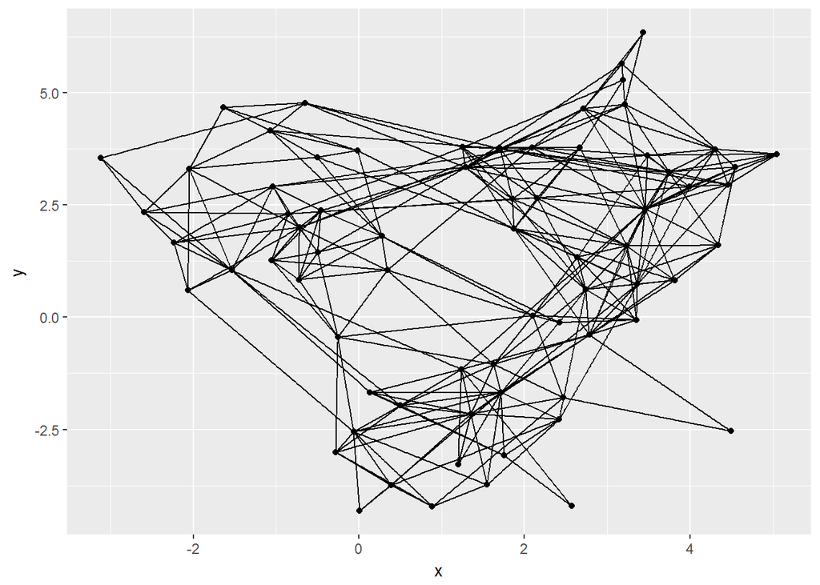

```r
## If you don't select a layout the program will pick one for you but it may not be exactly what you need. It's best to read about the different layouts and pick the one that fits your data/purpose.

ggraph(friends_graph) +
   geom_edge_link() +
    geom_node_point()
```

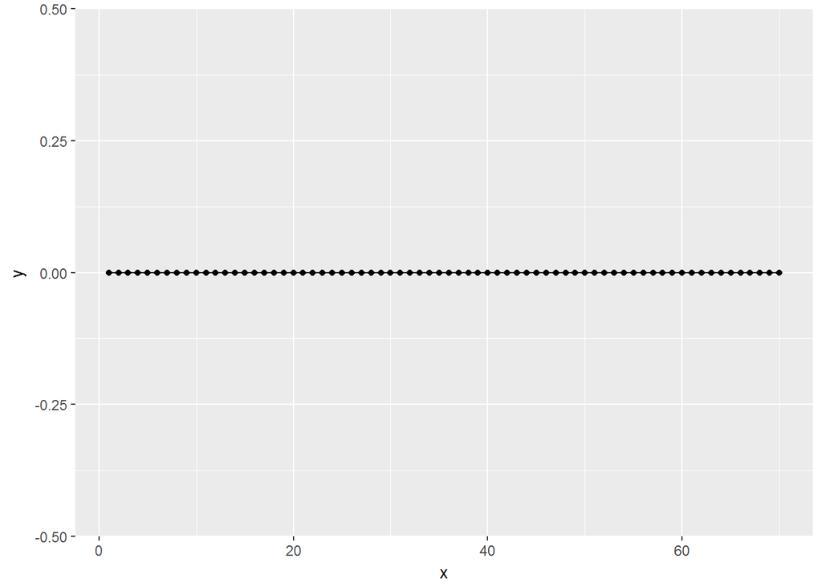

```r
#For example, layout = "linear" isn't helpful.

ggraph(friends_graph, layout = "linear") +
   geom_edge_link() +
    geom_node_point()
```

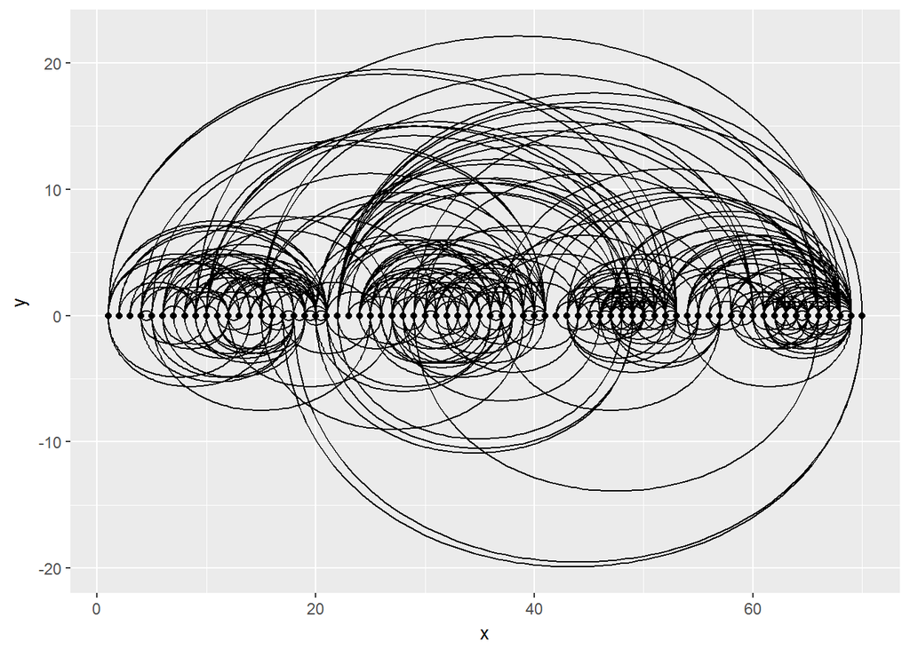

```r
##unless we change the edge, we'll try "geom_edge_arc" instead of "geom_edge_link". It's too messy but you can see how adjusting edges/nodes can change your network.

ggraph(friends_graph, layout = "linear") +
   geom_edge_arc() +
    geom_node_point()
```

Our first network was still unsatisfying and did not reveal very much. The appearance can be manipulated by adjusting aesthetics. We can also add a third variable to the network (year) in this case.

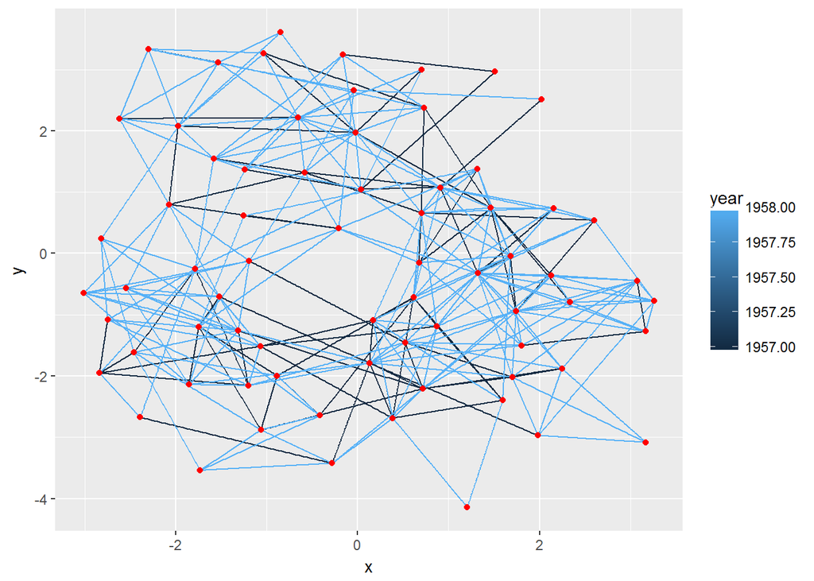

```r
##see ?layout_with_kk for more

ggraph(friends_graph, layout = "kk") +
  geom_edge_link(aes(color = year)) +
    geom_node_point(color = "red")
```

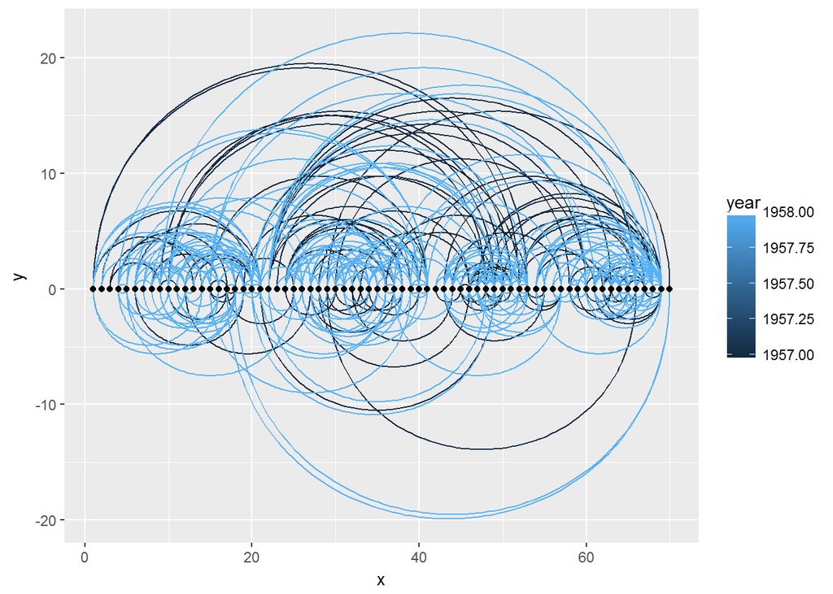

```r
##The arc demo looks different when we add color to it.

ggraph(friends_graph, layout = "linear") +
   geom_edge_arc(aes(color = year)) +
    geom_node_point()
```

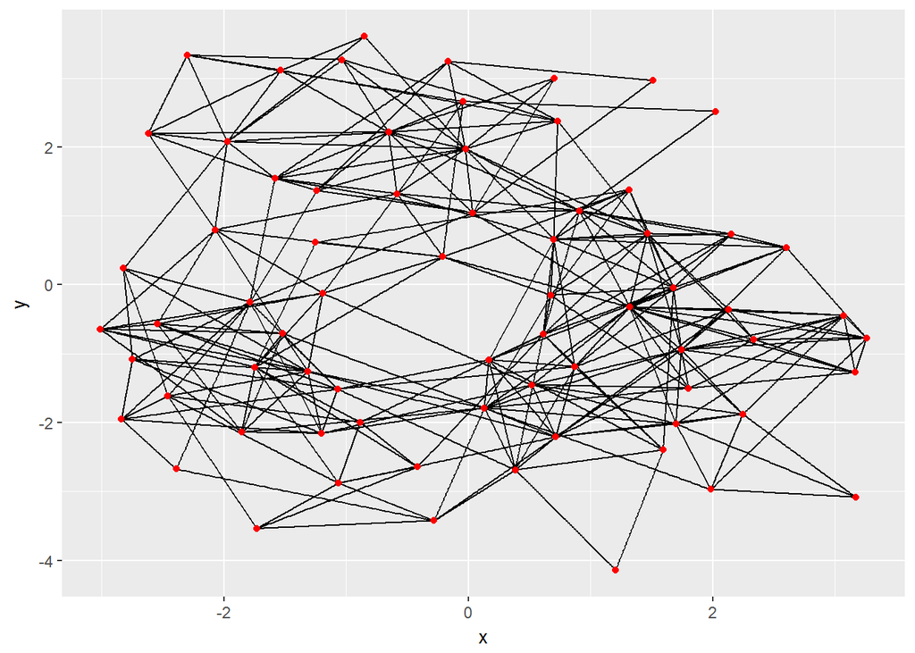

```r
ggraph(friends_graph, layout = "kk") +
  geom_edge_link() +
    geom_node_point(color = "red")
```

We can also use facet_edge which is similiar to facet_wrap.

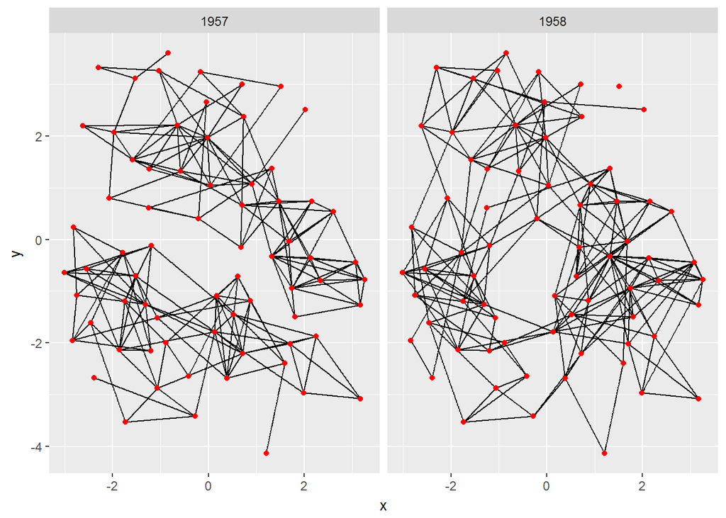

```r
ggraph(friends_graph, layout = "kk") +
  geom_edge_link() +
  geom_node_point(color = "red") +
  facet_edges(~year)
```

This is an interesting graph as we can see in 1957 a couple friend-clusters have formed with zero cross-over. A few future history majors can be seen on on the outskirts. Interestingly, the groups become interwoven in 1958. My guess is the lone node without an edge in 1958 may have been connected to a node in 1957.

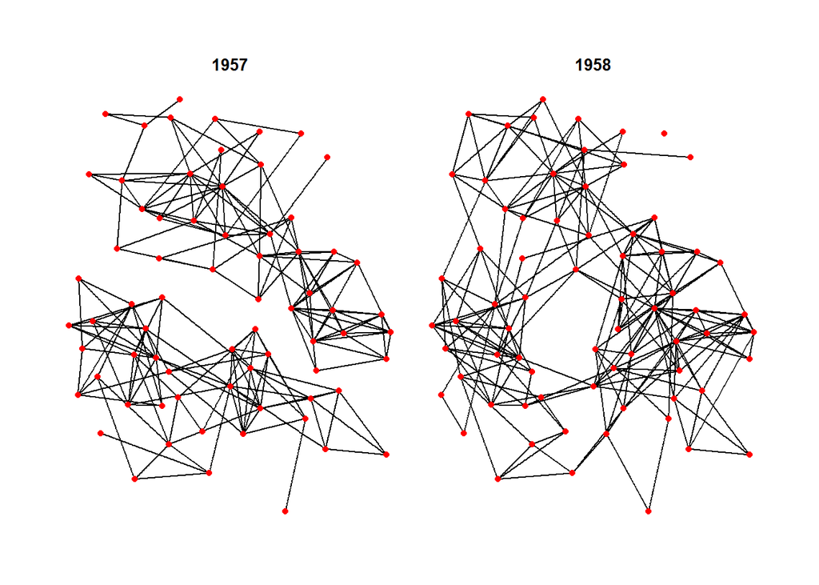

```r
## you can also make the graph more visually appealing by removing the grid.
ggraph(friends_graph, layout = "kk") +
  geom_edge_link() +
  geom_node_point(color = "red") +
  facet_edges(~year) +
  theme_graph()
```

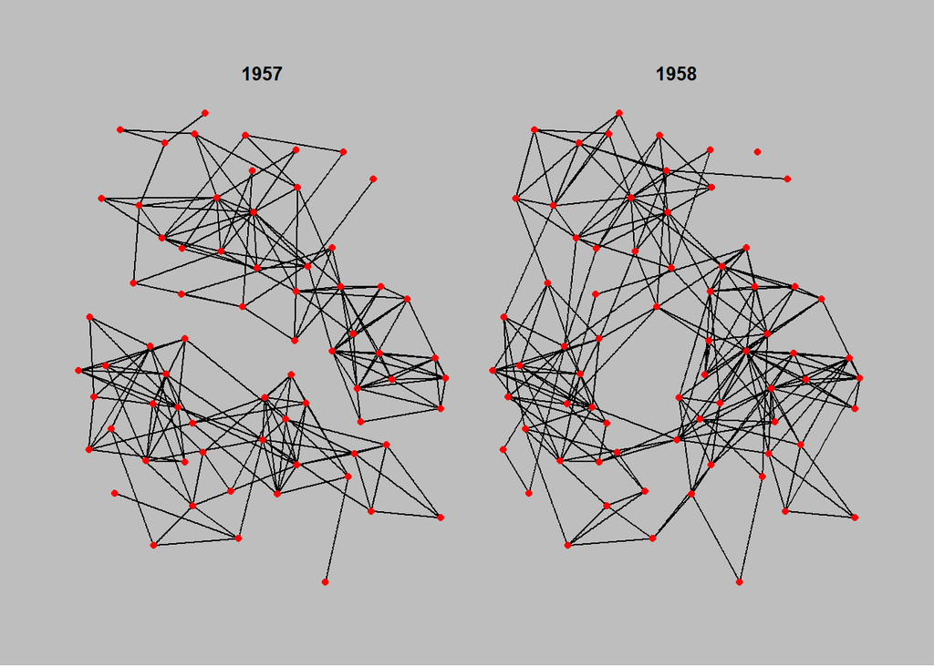

```r
## And adding a background color

ggraph(friends_graph, layout = "kk") +
  geom_edge_link() +
  geom_node_point(color = "red") +
  facet_edges(~year) +
  theme_graph(background = "grey")
```

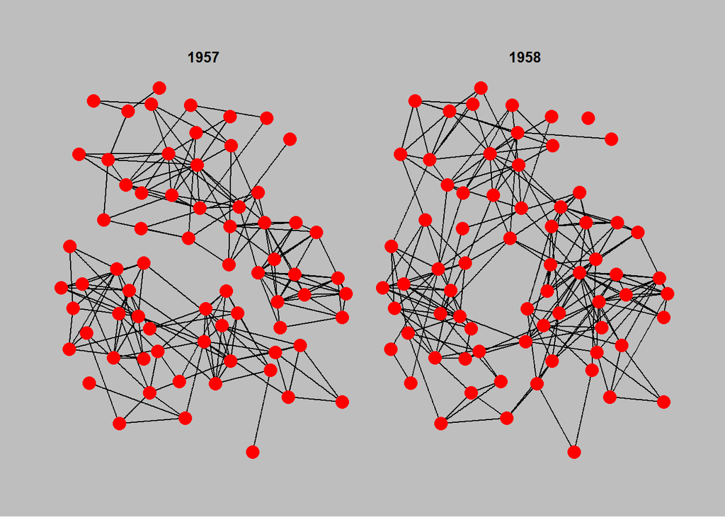

```r
## Change size of nodes (arbitrary size)

ggraph(friends_graph, layout = "kk") +
  geom_edge_link() +
  geom_node_point(color = "red", size = 4) +
  facet_edges(~year) +
  theme_graph(background = "grey")
```

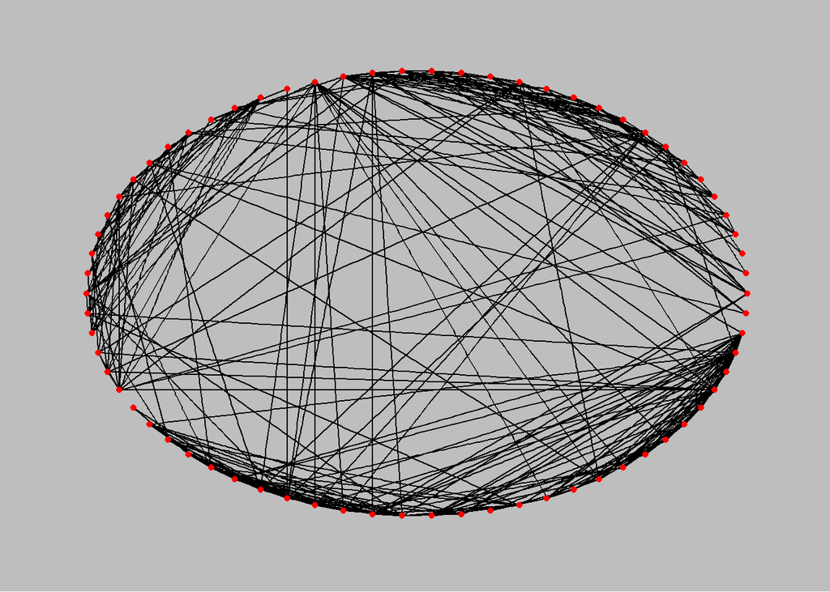

```r
## There are many different layouts you can experiment with.

ggraph(friends_graph, layout = "circle") +
  geom_edge_link() +
  geom_node_point(color = "red") +
  theme_graph(background = "grey")
```

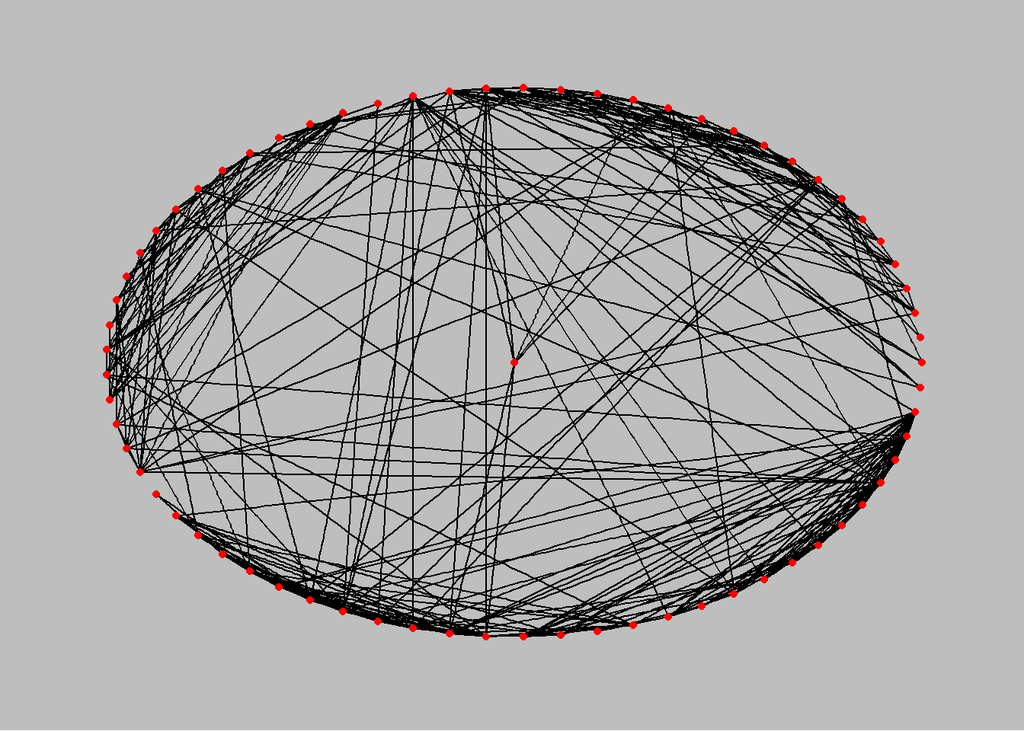

```r
ggraph(friends_graph, layout = "star") +
  geom_edge_link() +
  geom_node_point(color = "red") +
  theme_graph(background = "grey")
```

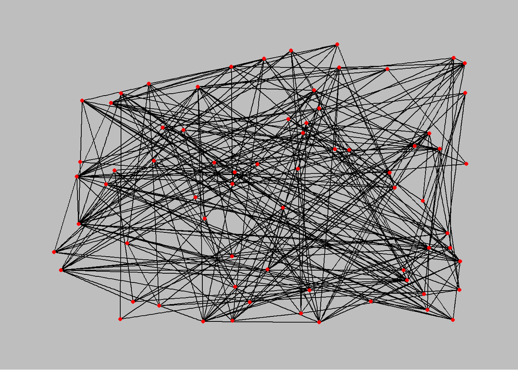

```r
ggraph(friends_graph, layout = "randomly") +
  geom_edge_link() +
  geom_node_point(color = "red") +
  theme_graph(background = "grey")
```

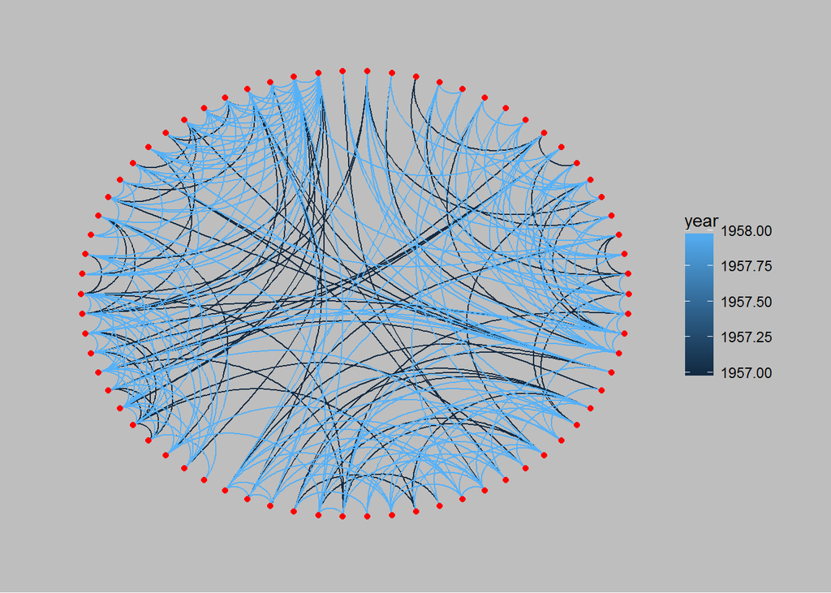

```r
ggraph(friends_graph, layout = "linear", circular = TRUE) +
  geom_edge_arc(aes(color = year)) +
  geom_node_point(color = "red") +
  theme_graph(background = "grey")
```

Other things you can do with ggraph:

Tile graphs

Hierarchical Layouts: Treemaps Dendrograms

Change size of nodes, the graph, etc. Plus more optinos for layouts, nodes, and edges.

Add arrows to edges (to show reciprocity in relationships I believe)

Incomplete code (wasn’t able to fix error before class). With corrections, this would allow you to calculate the degree of a node, I believe based on how many edges connect to it, and then use that as a variable. This would allow you to change the size of the node based on how many edges connect to it.

```
friends_degree <- friends_graph %>%
  add_column(friends_graph, degree = degree(friends_graph))

friends_graph2 <- graph_from_data_frame(friends_degree)

ggraph(friends_graph2, layout = "star") +
  geom_edge_link() +
  geom_node_point(color = "red", size = degree) +
  theme_graph(background = "grey")
```

[^1]: https://www.rdocumentation.org/packages/ggraph/versions/0.1.1